# Project 1: What did the presidents say at their inauguation?

Mengqi Chen

##### The inaugural address has been a tradition set by the first president George Washington. It is made every four years by all the presidents before they take the office. Those political speeches are very important since the president’s fundamental political values and outline of his policy will be pronounced. Inaugurals in US provide a good indication of forthcoming political agenda.

##### An artical is made of sentences and a sentence consist of words. This report focus on analysing the basic part- words of inaugural speeches including the length of speeches, the lexical diversity and the frequency of words.

##### Prepare: Install packages; Set plot theme

```
##
##  /var/folders/wl/30lqtgk93jv4tqj_gt_hc50m0000gn/T//RtmpMaXNu9/downloaded_packages
```

# Part 1: Numbers of words

#### 1.1 The number of words used by each presidents

| name | file | term | party | words | year |
| --- | --- | --- | --- | --- | --- |
| George Washington | GeorgeWashington | 1 | NA | 1431 | 1789 |
| George Washington | GeorgeWashington | 2 | NA | 135 | 1793 |
| John Adams | JohnAdams | 1 | Fedralist | 2321 | 1797 |
| Thomas Jefferson | ThomasJefferson | 1 | Democratic-Republican Party | 1730 | 1801 |
| Thomas Jefferson | ThomasJefferson | 2 | Democratic-Republican Party | 2166 | 1805 |
| James Madison | JamesMadison | 1 | Democratic-Republican Party | 1177 | 1809 |

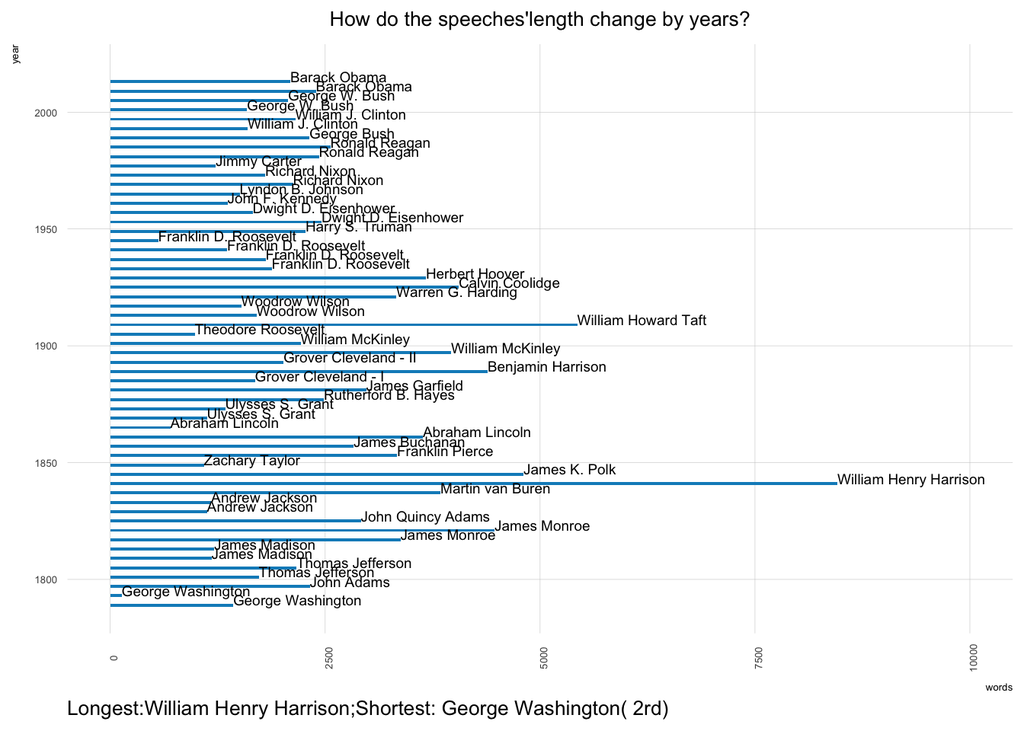

From the graph, President William Henry Harrison had the longest speech over 8000 words and George Wahington had the shortest one only 135 words in his second term.

Highly influential Presdents like Abraham Lincoln, Franklin Delano Roosevelt, George Washington, Renold Reagan seem have shorter speech comparatively.

```
## [1] "inaugAbrahamLincoln-1.txt" "inaugAbrahamLincoln-2.txt"
## [3] "inaugAndrewJackson-1.txt"
```

```
## [1] 58
```